# Technical Report: CIP Sea Level and Coastal Inundation Workflow

Authors: Julian O'Grady, Rebecca Gregory, Tim Erwin, Mark Hemer and Kathleen McInnes. CSIRO Environment, Australia.

'VERSION 1.0: Report generated 2024-06-20 13:20:20'

## Overview

Coastal communities face an uncertain future when considering the threat of ocean flooding from potentially catastrophic storms coinciding with high tides and rising mean sea levels. Even with ambitious global Green House Gas (GHG) mitigation targets, we are confident sea levels will continue to rise in excess of 0.28m from 2005 to 2100 (IPCC, Fox-Kemper et al., 2021), which will cause an exponential increase in coastal flooding. However, uncertainties remain in IPCC sea level projections and in the estimation of design storm characteristics, e.g., a 1 in 100 year event, associated with extreme model fits to limited (<100 years) observation records. There are also assumptions that the stochastic properties of the extreme sea level storm driven events are stationary and won’t undergo a future “tipping point” step change in weather regimes. **These future uncertainties and assumptions in flooding levels should be considered in an assessment of hazard and risk to our coastal assets.**

This report, and the accompanying data, provides estimates of the likely range (uncertainty) of how high future design storms will reach using tide gauge observations and numerical simulations of historic extreme water levels with future mean sea level projections from the sixth IPCC assessment report (AR6). Also provided are details on the input data and methods used to map probabilistic flood zones for individual local government areas (LGA) using spatial model techniques that account for wave action, local beach geomorphology, and ocean hydrological conductivity of flooded areas. The provided LGA probabilistic flood zone maps allow users to identify which low lying land is most likely to be affected and which land is less likely to be affected for a future year, global GHG Shared Socioeconomic Pathway (SSP) and Average Recurrence Interval (ARI) design storm. When selecting a future year and ARI the user should consider their risk appetite for failure, the design life of the assets, asset depreciation, planning horizon and the probability of the asset being impacted [Engineers Australia 2015](https://arr.ga.gov.au/__data/assets/pdf_file/0003/40548/ARR_Project_20_Stage3_Report.pdf). Users should also consider more than one GHG SSP to explore the impact of future GHG mitigation pathways.

Users of the data generated in this work should be aware of the difference between ARI and AEP (Annual Exceedance Probability) and how to communicate the difference between ARI and AEP in a changing climate, mainly driven by global sea level rise (SLR) ([see New-ARR-Probability-Terminology](https://arr.ga.gov.au/__data/assets/pdf_file/0006/40398/New-ARR-Probability-Terminology_final.pdf), Ball et. al. 2019). Considerations should also be made to other sources of uncertainty and bias in coastal flood risk studies, such as accounting for local adaptation ([Hinkel et. al. 2021](https://doi.org/10.1029/2020EF001882)).

The remainder of the report details the data and methodology for generating the inundation layers. The final section details the output layers and data and then identifies limitations of the analysis.

### Probabilistic inundation layer

Probabilistic layers were previously developed for the Port Philip Bay Coastal Hazard Assessment (McInnes et. al. 2022). Inundation layers are provided here as four zones (Zone 1, Zone 2, Zone 3 and Zone 4) representing high to low probability land will be affected (greater than 95%, between 95% and 50%, between 50% and 5% and less than 5%). Where the upper (most inland) bound of the zones are equivalent to quantile estimates (5th, 50th, 95th and 95th plus a freeboard to include ocean wave effects). The landward bound of the blue Zone 2 is equivalent to a more commonly used deterministic "one value" estimate of inundation. These probabilistic ranges are consistent with the IPCC Global Climate Model (GCM) ensemble estimates, and cover the likely range, representing 90% uncertainty, i.e. the 5th to 95th quantile, with the exception of the low confidence SSP5-8.5 estimates which span the 17th to 83rd quantile. Figure 1 illustrates how land closest to the sea under the Zone 1 purple areas are most likely to be flooded, followed by the blue Zone 2, with the light blue Zone 3 less likely to be impacted. Inundation landward of Zone 3 is possible, but less likely and is represented by the grey Zone 4 using an additional freeboard to account for unresolved processes, notably the inundation effect of waves and damaging surf (wave setup).

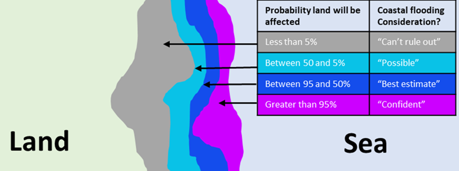

*Figure 1 Idealised map of the probabilistic flood hazard zones. The coastal flooding consideration terminology does not suggest or indicate any legal definitions of likelihood.*

### Extreme Sea Level Components

How high the sea can reach up the coast depends on the co-occurrence of future mean sea levels (seasonal, interannual and with climate change), tides and atmospheric driven storm surge (storm-tide). A vertical datum is also required to align water heights with surveyed land levels from a digital elevation model (DEM). All these components have uncertainty in their estimates as illustrated in Figure 2.

The total water level return level (TWLRL) is the combination of sea level rise from the Australian Height datum (AHD) to the AR6 baseline (AHD2AR6), local mean sea level variability (MSLV), future AR6 sea level rise (SLR), storm tide ARI return level (STRL) and the freeboard representing wave setup (WSRL). Three other levels are presented in Figure 2 to elaborate the mean sea level (MSL), still water level (SWL) and freeboard level (FBL). A further summary of the components in Figure 2 are presented in Table 1 and provided in detail for your LGA in the report subheadings below. Zone 1, 3 and 4 TWLRL estimates were made using [error propagation](http://science.clemson.edu/physics/labs/tutorials/errorp/index.html), by looking at the uncertainty from the maximum likely estimate (Zone 2), represent as ∆ in the equations below, where the overall uncertainty is calculating the Euclidean distance of the components listed in Table 1.

$ \Delta_{TWLRL} = \sqrt{\Delta^2_{AHD2AR6} + \Delta^2_{MSLV} + \Delta^2_{SLR} + \Delta^2_{STRL} + \Delta^2_{WSRL}} $

$ TWLRL_{Zone2} = AHD2AR6 + SLR + STRL $

$ TWLRL_{Zone1} = TWLRL_{Zone2} - \Delta_{TWLRL} (\Delta_{WSRL} = 0) $

$ TWLRL_{Zone3} = TWLRL_{Zone2} + \Delta_{TWLRL} (\Delta_{WSRL} = 0) $

$ TWLRL_{Zone4} = TWLRL_{Zone2} + \Delta_{TWLRL} $

[figure not shown]

*Figure 2 Idealised cross section of the contributors to probabilistic extreme sea levels corresponding to those listed in Table 1.*

*Table 1 Summary of sea level contributors to probabilistic extreme sea levels.*

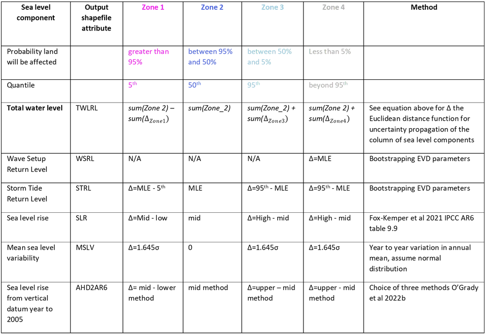

### Bathtub flood method

A ‘bathtub’ or ‘bucket fill’ model is a common method for identifying areas potentially at risk from coastal flooding (e.g. [ESA](https://data.environment.sa.gov.au/Coast-and-Marine/Data-Systems/Coastal-Flood-Mapping-Viewer/Pages/default.aspx)). This is a simple method that identifies any DEM land below a certain water level elevation as being at risk of flooding, like pouring water into a bathtub or bucket. Bathtub flood modelling is a relatively quick and effective method of identifying potential risk at a large or regional scale. Bathtub flood fill is a simplified method for identifying land subject to the hazard of ocean flooding, which does not consider the effectiveness of coastal protection (dykes and seawalls) and flood adaptation measures (drainage and retention reservoirs) to prevent flooding of low lying land from the sea. Bathtub also represents instantaneous flooding, where in reality the hydraulic connectivity, and water flowing over and around land obstacles (vegetation, buildings) attenuates the flooding, preventing it from reaching inland bathtub flood extents at the ocean water level. In addition, inundation from hazardous surf conditions (wave setup and runup) typically only extends to backshore regions, tens of metres from the shoreline.

**The factors that should be considered when interpreting the resulting bathtub inundation layer include:**

1. Where there is 100% **effective** coastal protection (e.g. dykes, sea walls) represented in the DEM, bathtub will unrealistically map large parts of land behind coastal protection as currently flooded with sea water, and will exaggerate the inland flood extent, where in reality the coastal protection, typically dykes and seawalls, will prevent this flooding from occurring.
2. However, where there is **ineffective** coastal protection (untested by huge storms or in an aging state) represented in the DEM, bathtub mapped inundation locations behind structures are still **hazardous** considering that the coastal defence (dyke wall) could fail (break).
3. The **unintended** impact of coastal protection is that it can trap water from heavy rains or bulging rivers being released during coincident rainfall and high sea level events, and the water can’t be easily released out to sea.
4. Having noted this, a **freeboard** is often considered in hazard assessments for unexpected factors, such as damaging surf effects (wave setup), failed adaptation measures (drainage blockages), sedimentation in waterways.
5. Simple spatial processing can also identify if flood areas are connected (intersects) with the sea or not, to aid in identifying the source of flooding.

For further consideration, an example comparison of the bathtub and dynamical inundation method is provided in [Didier et al. 2019](https://onlinelibrary.wiley.com/doi/full/10.1111/jfr3.12505)

## Data and Methods

The software automatically generated a html document which summarises the technical details and inputs to map the hazard of sea level rise (SLR) for individual local government authorities (LGA). The input of data and generation of layers is described in five steps:

1. User input parameters (LGA, future year, SSP, design storm ARI)
2. Software reads in corresponding 5m DEMS, tide gauges water levels and wave setup estimates.
3. Software calculates water levels for historic SLR from AHD to the AR6 baseline (AHD2AR6), local mean sea level variability (MSLV), future SLR, storm average recurrence interval (ARI) return level (RL) and wave setup.
4. Software combines probabilistic water levels and maps bathtub inundation for each tile.
5. Output data and report in vector “geoJSON” and “shp” shape file formats.

### 1. Automated report user input parameters

Users have the option to select an LGA from [LGA_2023_AUST_GDA2020](https://www.abs.gov.au/statistics/standards/australian-statistical-geography-standard-asgs-edition-3/jul2021-jun2026/access-and-downloads/digital-boundary-files) (where there is available water level and land elevation data) to compute the hazard layers. Hazard overlays represent the future time up to 2150, for SSPs 1-2.6, 2-4.5, 3-7.0, 5-8.5 and 5-8.5 low confidence (Fox-Kemper et al 2021) and for any design [ARI](https://tonyladson.wordpress.com/2017/07/04/converting-between-ey-aep-and-ari/). Note, Table 9.10 in Fox-Kemper et. al. (2021) indicates the closest SSP to global degrees warming of 1.5, 2, 3, 4 degrees Celsius is SSP 1-2.6, 1-2.6/2-4.5, 2-4.5/3-7.0, 3-7.0, 5-8.5 respectively.

```
This report is generated for the Onkaparinga LGA for the year 2050 under the SSP2_4_5 pathway considering a 100 year ARI design storm.
```

```
Files are output to /datasets/work/ev-ci-cih/work/coastal_inundation/ACS/Onkaparinga/Onkaparinga_year2050_SSP2_4_5_ARI100
```

```
Probabilistic flood overlays for Onkaparinga LGA represent a 100 ARI event for the year 2050 following the SSP2_4_5 pathway
```

### 2. Input data for inundation tiles

The coast of Australia was broken up into 4029 tiles, each tile is ~5km wide and extends ~5km inland. Tiles overlapping the user selected 2023 LGA shapefile were used in this report. Tide gauge water levels were sourced online from [GESLA3](https://gesla787883612.wordpress.com/downloads/) and requested from Manly Hydraulics Lab (MHL). A previous national assessment used statewide estimates of extreme water levels to assess coastal inundation (DCC 2009). Here, water levels from 98 tide gauges were then mapped to neighbouring inundation tiles using expert judgement on how representative the gauge was. The selected tide gauges for each inundation tile in the LGA are shown in Figure 3. Wave setup estimates were derived from an empirical model with input from to spectral wave model hindcast simulations (Hemer et al., 2017; O’Grady et al., 2019).

For each tile an underpinning DEM was sourced from the [Digital Elevation Model (DEM) of Australia derived from LiDAR 5 Metre Grid](https://ecat.ga.gov.au/geonetwork/srv/eng/catalog.search#/metadata/89644) or downloaded from the online [ELVIS](https://elevation.fsdf.org.au/) platform for South Australia, Lord Howe Island, Cocos Keeling Island and Christmas Island. The grid derived from LiDAR surveys was cross checked with the sources LiDAR DEMS to confirm the vertical datum (AHD). The DEM files used in this report are presented in Figure 4.

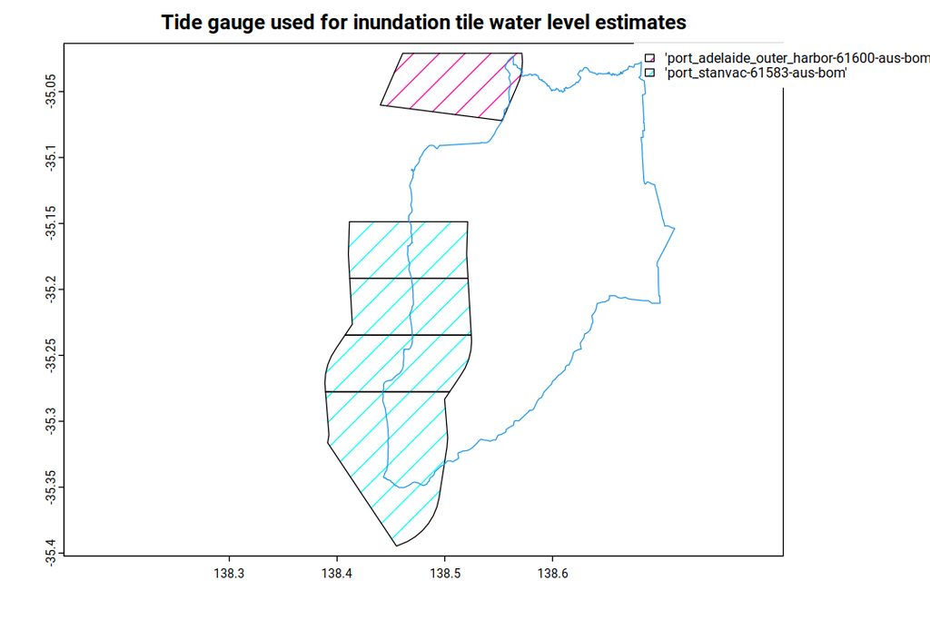

*Figure 3 Overlap of the LGA (blue line) and coastal inundation tile(s), hashed colours identify input GESLA3 tide gauge(s).*

[figure not shown]

*Figure 4 Overlap of the LGA (blue line) and coastal inundation tile(s), hashed colours identify input DEM(s).*

### 3. Calculation of water levels

#### Sea level rise from AHD to AR6 baseline periods (AHD2AR6)

Sea levels around Australia have changed since the Australian Height Datum (AHD) was developed in the late 1960s and early 1970s. IPCC AR6 future sea level rise (SLR) projections are relative to a baseline period centred on 2005 (1995 to 2014), so the amount of SLR from AHD to 2005 must be accounted for. Sea level rise from AHD to the AR6 baseline were sourced from (O'Grady et al 2022). The uncertainty is derived from three different methods computing the amount of sea level rise:

1. Mean sea level (1995 to 2014) less (minus) the AHD survey value.
2. Mean sea level (1995 to 2014) less (minus) mean sea level (1967-1969) for mainland Australia and (1971) for Tasmania.
3. The linear trend in tide gauge sea level per year (1976-2014) multiplied by the number of years (2005-1967).

The quality of all three methods was dependant on how complete the tide gauge record was over the analysis period. This was determined as 90% of the record period for method 1, 80% for 2 and 65% for 3. The estimates were mapped onto a string of coastal points around Australia separated by 5km using the nearest neighbour method in the R package “terra”. This was preferred over linear interpolation which would interpolate across the continent (not just capes and peninsulas) and extrapolate to remote islands (Haigh et. al. 2014). At each coastal point, the model representing the median (middle) value was considered to represent a best estimate.

The year to year variability in sea level around the IPCC 20-year mean global sea levels was considered in the extreme water levels. Interannual mean sea level variability (MSLV) was estimated from the root mean square error (RMSE) from a linear fit to annual mean sea level for all years in the tide gauge record. Annual values from the tide gauge are shown in Figure 5, along with MSLV added to the outer extents of the IPCC likely projected SLR as a demonstration of the additional uncertainty in MSL projections from interannual variability.

#### Sea level rise (SLR)

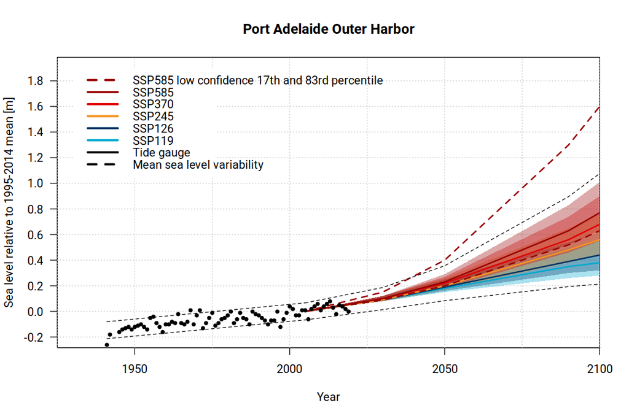

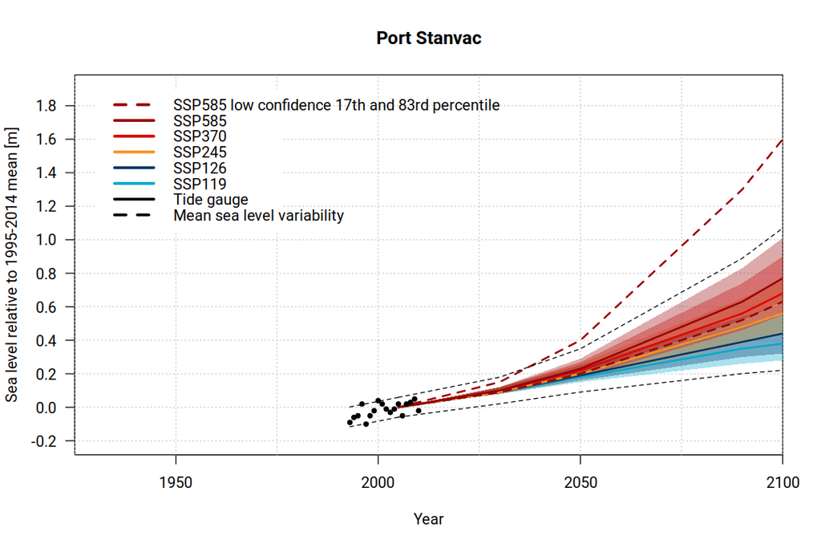

*Figure 5 Plume plots for the global mean sea level projections for different SSPs from the IPCC AR6 assessment report. The data from the nearest tide gauge is overlaid (black dots) with the MSLV (dashed black line). Future MSLV dashed lines (post 2005) are the MSLV added to the high end SSP585 projection and removed from the low end SSP119. See the appendix for tabulated values.*

#### Storm tide return level (STRL)

Storm tide was defined as the annual maximum water level minus (less) the annual mean water level and return levels. Table 2 shows the top 10 storm tide events for available tide gauges.

STRL are computed using a Gumbel extreme value distribution fit using R's [evd package](https://cran.r-project.org/web/packages/evd/index.html). Here, a uniform approach was desired, where the Gumbel EVD was previously identified to represent extreme water levels around Australia (Haigh et. al., 2014). Uncertainty bounds were computed from the quantiles of 100 Monte Carlo simulations of n sampled Gumbel fitted model values, where n is the number of years in the tide gauge record (O’Grady et. al., 2022a). Figure 6 plots the return level and uncertainty for the available tide gauges. Table 3 details the parameters of the Gumbel distribution and Table 4 lists a selection of ARI STWLs.

**$`'port_adelaide_outer_harbor-61600-aus-bom'`**

A data.frame: 10 × 7

|  | annMax <dbl> | annMean <dbl> | datestr <int> | date <chr> | pc_complete <dbl> | year <chr> | ST <dbl> |
| --- | --- | --- | --- | --- | --- | --- | --- |
| 77 | 3.797 | 1.41 | 2016050908 | 2016-05-09 08:00:00 | 100 | 2016 | 2.387 |
| 68 | 3.707 | 1.38 | 2007070410 | 2007-07-04 10:00:00 | 100 | 2007 | 2.327 |
| 42 | 3.679 | 1.36 | 1981070308 | 1981-07-03 08:00:00 | 91 | 1981 | 2.319 |
| 21 | 3.549 | 1.26 | 1960051208 | 1960-05-12 08:00:00 | 99 | 1960 | 2.289 |
| 6 | 3.479 | 1.20 | 1945062608 | 1945-06-26 08:00:00 | 100 | 1945 | 2.279 |
| 56 | 3.569 | 1.29 | 1995071307 | 1995-07-13 07:00:00 | 100 | 1995 | 2.279 |
| 33 | 3.479 | 1.23 | 1972062808 | 1972-06-28 08:00:00 | 98 | 1972 | 2.249 |
| 14 | 3.489 | 1.24 | 1953051808 | 1953-05-18 08:00:00 | 100 | 1953 | 2.249 |
| 70 | 3.654 | 1.42 | 2009042507 | 2009-04-25 07:00:00 | 100 | 2009 | 2.234 |
| 60 | 3.548 | 1.35 | 1999061307 | 1999-06-13 07:00:00 | 100 | 1999 | 2.198 |

**$`'port_stanvac-61583-aus-bom'`**

A data.frame: 10 × 7

|  | annMax <dbl> | annMean <dbl> | datestr <int> | date <chr> | pc_complete <dbl> | year <chr> | ST <dbl> |
| --- | --- | --- | --- | --- | --- | --- | --- |
| 17 | 3.350 | 1.19 | 2007070410 | 2007-07-04 10:00:00 | 100 | 2007 | 2.160 |
| 5 | 3.239 | 1.12 | 1995071308 | 1995-07-13 08:00:00 | 100 | 1995 | 2.119 |
| 4 | 3.186 | 1.11 | 1994052507 | 1994-05-25 07:00:00 | 100 | 1994 | 2.076 |
| 19 | 3.234 | 1.22 | 2009042507 | 2009-04-25 07:00:00 | 100 | 2009 | 2.014 |
| 9 | 3.126 | 1.15 | 1999061307 | 1999-06-13 07:00:00 | 100 | 1999 | 1.976 |
| 10 | 3.123 | 1.21 | 2000062109 | 2000-06-21 09:00:00 | 100 | 2000 | 1.913 |
| 13 | 3.047 | 1.14 | 2003051808 | 2003-05-18 08:00:00 | 99 | 2003 | 1.907 |
| 8 | 2.984 | 1.12 | 1998072709 | 1998-07-27 09:00:00 | 100 | 1998 | 1.864 |
| 18 | 2.969 | 1.20 | 2008072008 | 2008-07-20 08:00:00 | 100 | 2008 | 1.769 |
| 7 | 2.835 | 1.07 | 1997060607 | 1997-06-06 07:00:00 | 100 | 1997 | 1.765 |

*Table 2 Top 10 annual maximum (annMax), mean (annMean) and storm tide events for the available tide gauge(s). Pc_complete indicates the percentage of hourly data available per year. ST is the storm-tide (annMax less annMean).*

A data.frame: 2 × 12

|  | mle_1 <dbl> | mle_2 <dbl> | cov_11 <dbl> | cov_12 <dbl> | cov_21 <dbl> | cov_22 <dbl> | AIC <dbl> | Name <chr> | nCompleteYears <int> | lon <dbl> | lat <dbl> | sd_residual_lm <dbl> |
| --- | --- | --- | --- | --- | --- | --- | --- | --- | --- | --- | --- | --- |
| 31 | 1.866890 | 0.1467499 | 0.0003112564 | 7.107625e-05 | 7.107625e-05 | 0.0001599840 | -51.93606 | 'port_adelaide_outer_harbor-61600-aus-bom' | 77 | 138.4807 | -34.7798 | 0.04033725 |
| 125 | 1.767177 | 0.1280280 | 0.0010088583 | 2.427079e-04 | 2.427079e-04 | 0.0005995165 | -12.56830 | 'port_stanvac-61583-aus-bom' | 18 | 138.4670 | -35.1086 | 0.03594639 |

*Table 3 Gumbel extreme value distributions for the available tide gauge(s). mle_1 is the location parameter, mle_2 is the scale parameter, cov_XX represents the covariate matrix.*

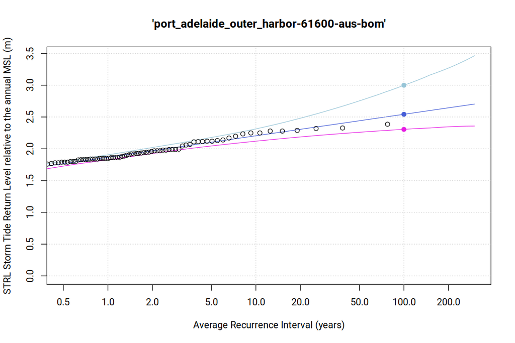

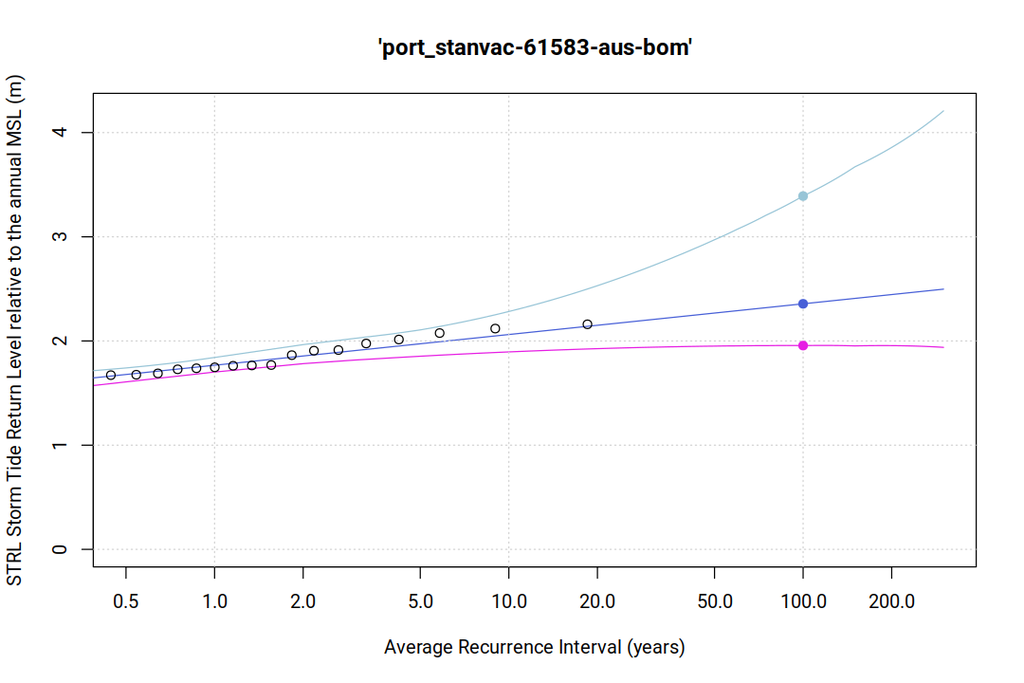

*Figure 6 Return level plots for the observed tide gauge(s) storm tide (ST) points, gumbel fit and 90% confidence interval. Solid points are the Zone estimates for the selected ARI*

1. A data.frame: 6 × 4

   |  | ARIs <dbl> | 95th <dbl> | 50th <dbl> | 5th <dbl> |
   | --- | --- | --- | --- | --- |
   | 10 | 1 | 1.826527 | 1.866890 | 1.904560 |
   | 20 | 10 | 2.119815 | 2.204794 | 2.313067 |
   | 30 | 20 | 2.186188 | 2.306513 | 2.481487 |
   | 60 | 50 | 2.260036 | 2.440979 | 2.753954 |
   | 110 | 100 | 2.305149 | 2.542698 | 2.999995 |
   | 210 | 200 | 2.345457 | 2.644417 | 3.270529 |

2. A data.frame: 6 × 4

   |  | ARIs <dbl> | 95th <dbl> | 50th <dbl> | 5th <dbl> |
   | --- | --- | --- | --- | --- |
   | 10 | 1 | 1.701863 | 1.767177 | 1.841795 |
   | 20 | 10 | 1.895021 | 2.061972 | 2.282970 |
   | 30 | 20 | 1.926291 | 2.150715 | 2.530598 |
   | 60 | 50 | 1.950776 | 2.268026 | 2.971721 |
   | 110 | 100 | 1.955668 | 2.356768 | 3.391674 |
   | 210 | 200 | 1.955446 | 2.445510 | 3.857912 |

*Table 4 Selection of storm tide ARIs for the available tide gauge(s).*

#### Wave setup return level (WSRL)

Wave setup is defined as the increase in the mean water level across the surf zone due to the presence of waves and can be a major contributor to inundation for coastlines exposed to large waves. Wave setup provides the mean contribution of waves to the shoreline water level. Detailed information and guidance including information on the equations are provided in [O'Grady et. al. 2019](https://doi.org/10.1029/2018JC014871) . Wave setup typically occurs (and has been studied) in the surf zone and on the beach face. However, when considering potentially catastrophic storms, wave setup is commonly applied as an additional freeboard to the storm tide level to account for additional wave driven inundation for inland bathtub flood extents.

The 'rule of thumb' basic understanding of the contribution of waves to increases in water levels is that wave setup is a percentage of the offshore significant wave height (Ho), wave setup = 0.31 Ho. This equation has also been calibrated to account for beach slope (Beta), wave setup = 3.71 Beta Ho. Wave setup estimates are provided for the rule of thumb method considering a beach slope.

Input wave heights were sourced from the nearest grid point (deeper than 20m) from the ERA5-WAM wave model [Hersbach et. al. 2020](https://doi.org/10.1002/qj.3803). A representative beach slope was calculated from the mean slope for all beaches within the LGA from [Vos et. al. 2021](https://doi.org/10.5194/essd-14-1345-2022)

#### Total water level return level (TWLRL)

The total water level (TWL) represents the combined contribution of ocean processes to extreme sea level (with or without wave setup freeboard) in Table 1. Table 5 shows the TWL for each inundation tile and Table 6 shows the components to TWLRL for each tide gauge.

A data.frame: 9 × 6

| id <int> | Name <chr> | TWLRLlow <dbl> | TWLRLmid <dbl> | TWLRLhig <dbl> | TWLRLfre <dbl> |
| --- | --- | --- | --- | --- | --- |
| 2245 | 'port_stanvac-61583-aus-bom' | 2.24 | 2.65 | 3.68 | 3.80 |
| 2254 | 'port_stanvac-61583-aus-bom' | 2.24 | 2.65 | 3.68 | 3.80 |
| 2260 | 'port_stanvac-61583-aus-bom' | 2.21 | 2.62 | 3.65 | 3.77 |
| 2265 | 'port_stanvac-61583-aus-bom' | 2.21 | 2.62 | 3.65 | 3.77 |
| 2276 | 'port_adelaide_outer_harbor-61600-aus-bom' | 2.59 | 2.83 | 3.30 | 3.52 |
| 2245 | 'port_stanvac-61583-aus-bom' | 2.24 | 2.65 | 3.68 | 3.80 |
| 2254 | 'port_stanvac-61583-aus-bom' | 2.24 | 2.65 | 3.68 | 3.80 |
| 2260 | 'port_stanvac-61583-aus-bom' | 2.21 | 2.62 | 3.65 | 3.77 |
| 2265 | 'port_stanvac-61583-aus-bom' | 2.21 | 2.62 | 3.65 | 3.77 |

*Table 5 Low (5th), mid (50th) and high (95th) quantile total water level for the inundation tile identifyer (id).*

A data.frame: 3 × 7

|  | Name <chr> | AHD2AR6low <dbl> | MSLVlow <dbl> | SLRlow <dbl> | STRLlow <dbl> | WSRLlow <dbl> | TWLRLlow <dbl> |
| --- | --- | --- | --- | --- | --- | --- | --- |
| 1 | 'port_stanvac-61583-aus-bom' | -0.03 | -0.06 | -0.03 | -0.40 | NA | 2.243306 |
| 3 | 'port_stanvac-61583-aus-bom' | -0.01 | -0.06 | -0.03 | -0.40 | NA | 2.214291 |
| 5 | 'port_adelaide_outer_harbor-61600-aus-bom' | -0.03 | -0.07 | -0.03 | -0.23 | NA | 2.585869 |

A data.frame: 3 × 7

|  | Name <chr> | AHD2AR6mid <dbl> | MSLVmid <dbl> | SLRmid <dbl> | STRLmid <dbl> | WSRLmid <dbl> | TWLRLmid <dbl> |
| --- | --- | --- | --- | --- | --- | --- | --- |
| 1 | 'port_stanvac-61583-aus-bom' | 0.09 | 0 | 0.2 | 2.36 | NA | 2.65 |
| 3 | 'port_stanvac-61583-aus-bom' | 0.06 | 0 | 0.2 | 2.36 | NA | 2.62 |
| 5 | 'port_adelaide_outer_harbor-61600-aus-bom' | 0.09 | 0 | 0.2 | 2.54 | NA | 2.83 |

A data.frame: 3 × 8

|  | Name <chr> | AHD2AR6hig <dbl> | MSLVhig <dbl> | SLRhig <dbl> | STRLhig <dbl> | WSRLhig <dbl> | TWLRLhig <dbl> | TWLtfre <dbl> |
| --- | --- | --- | --- | --- | --- | --- | --- | --- |
| 1 | 'port_stanvac-61583-aus-bom' | 0.01 | 0.06 | 0.06 | 1.03 | NA | 3.683538 | 3.798129 |
| 3 | 'port_stanvac-61583-aus-bom' | 0.02 | 0.06 | 0.06 | 1.03 | NA | 3.653683 | 3.768260 |
| 5 | 'port_adelaide_outer_harbor-61600-aus-bom' | 0.01 | 0.07 | 0.06 | 0.46 | NA | 3.299255 | 3.515711 |

*Table 6 Low (5th), mid (50th) and high (95th) total water level (TWLRL) and the water level components (AHD2AHR, MSLV, STRL and WSRL for the 50th quantile) for the nearest tide gauge. See Figure 1 and Table 1 for summary of water level component acronyms.*

#### DEM inundation layer processing

Raster cells were classified based on their depth relative to the TWLRL for each zone (Zone 1 to 4). These classified raster cells were then converted into vector polygons and merged into the LGA zone extents. A 50m buffer around the LGA coastline was applied to identify and label flooded areas connected to the sea. Any flood zones touching a zone identified as connected to the sea were also labelled accordingly, although, neighbouring LGA connection to the sea flooding was not considered in the analysis. Attributes such as zone number, colour, and transparency were assigned to each zone.

### 4. Summary of resulting output and report limitations

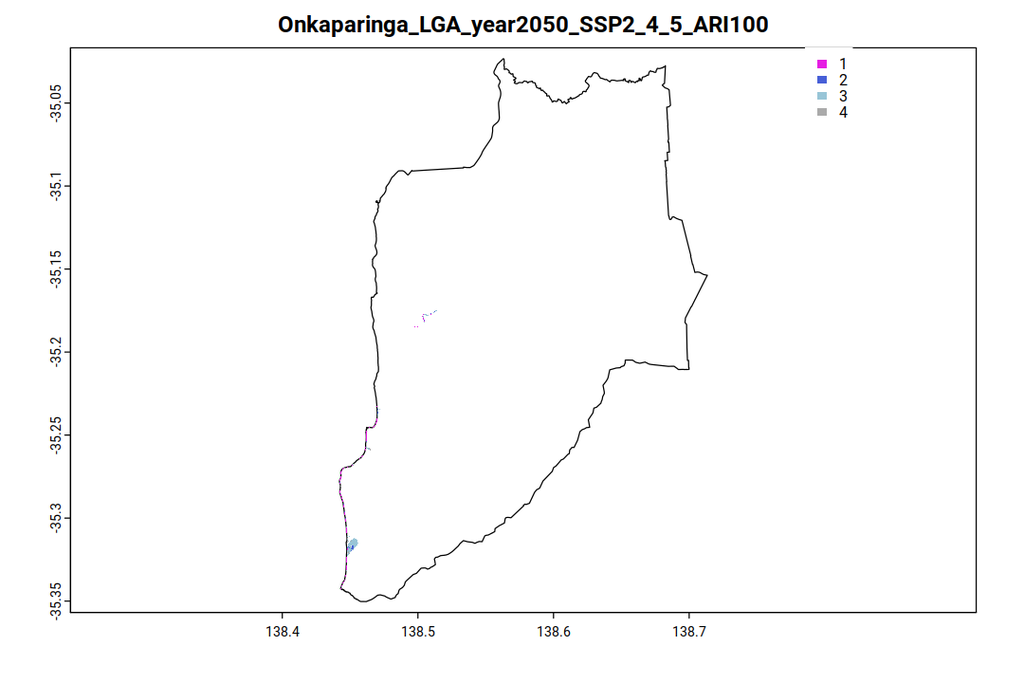

*Figure 7 Mapped hazard layers impacting coastal areas of LGA*

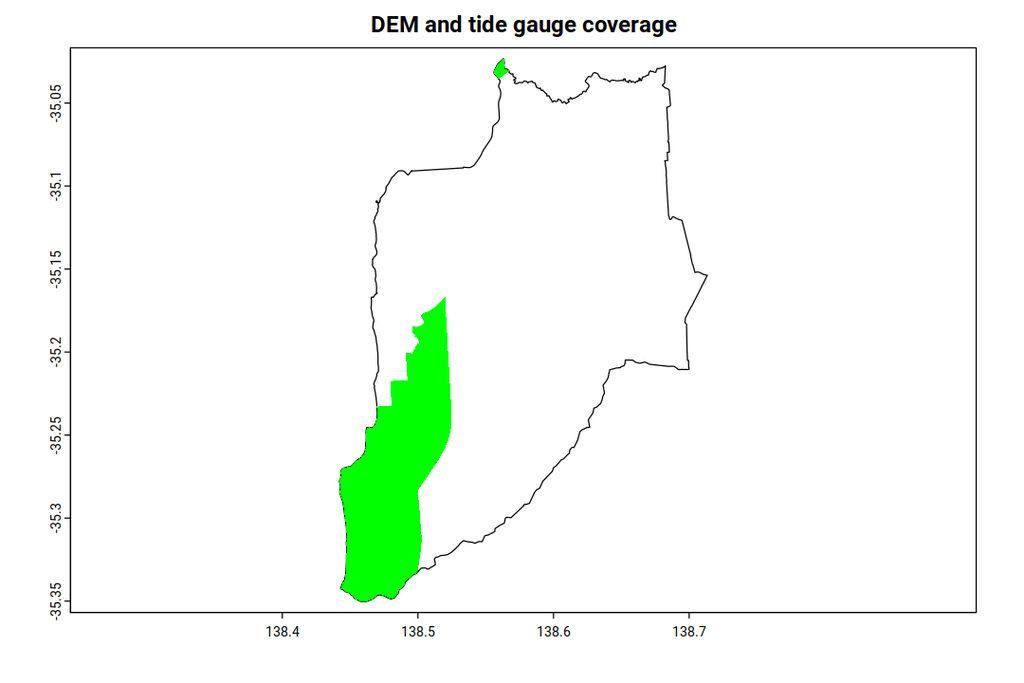

*Figure 8 Gridded elevation (DEM) and tide gauge coverage (green areas).*

```
[1] "/datasets/work/ev-ci-cih/work/coastal_inundation/ACS/Onkaparinga/Onkaparinga_year2050_SSP2_4_5_ARI100/Onkaparinga_DEM_and_tide_gauge_coverage.geoJSON"
 class       : SpatVector
 geometry    : polygons
 dimensions  : 1, 0  (geometries, attributes)
 extent      : 138.4421, 138.5673, -35.35025, -35.02323  (xmin, xmax, ymin, ymax)
 coord. ref. : lon/lat WGS 84 (EPSG:4326)
```

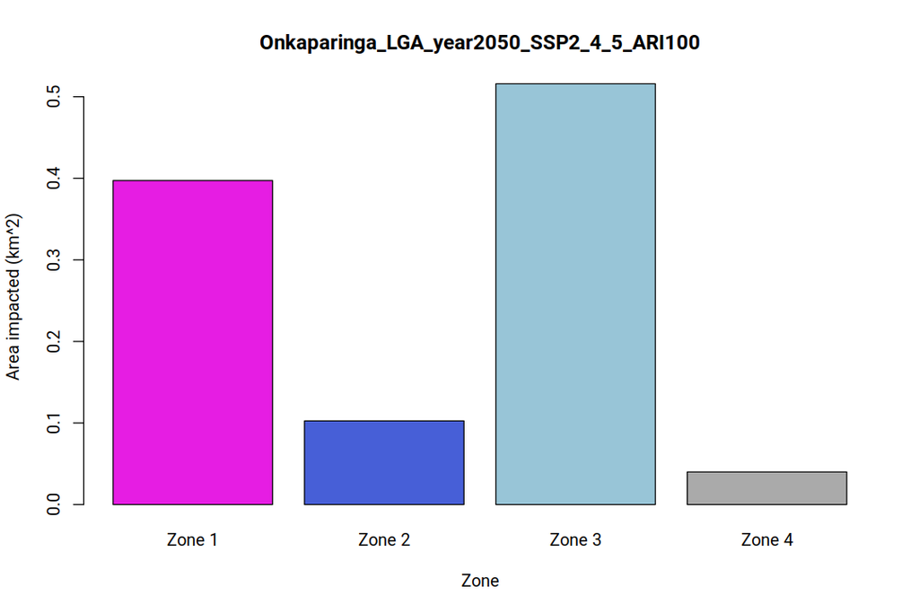

*Figure 9 Area of land within LGA boundary impacted different flooding zone probabilities.*

A data.frame: 5 × 2

| Zone <chr> | Area_km2 <dbl> |
| --- | --- |
| LGA | 518.1229 |
| Zone 1 | 0.3970 |
| Zone 2 | 0.1030 |
| Zone 3 | 0.5160 |
| Zone 4 | 0.0400 |

*Table 7: Area of the LGA and hazard zone overlays.*

The results from the automatically generated technical report can be used as the basis for a more detailed coastal inundation hazard assessment. The methods used here to map coastal inundation hazards from sea level rise and potentially catastrophic events for a single LGA have been developed to align with a repeatable nationally consistent framework/approach. Therefore, local scale effects and knowledge of historic events through expert consultation should be further considered when providing a more detailed hazard assessment to users.

The hazard layers provided do not include the processes of terrestrial flooding from rainfall runoff (flash or catchment flooding), nor does it consider urban adaptation infrastructure such as drainage and retention or time dependant flooding or dynamic hydraulic flow restrictions. However, the layers provided do identify if a flooded area is directly connected to the sea or not (50m from the LGA coastline). The processes of transient swash wave runup and overtopping are not directly captured. However, a freeboard is included to represent inundation from dangerous surf (wave setup), and when used with the liberal bathtub filling method, the freeboard is expected to accommodate some of the wave runup and overtopping impacts. The underlying DEM to predict future inundation does not change, i.e. there is no consideration of future coastal erosion or changes to the coastal protection of assets. The tide gauge observations used to estimate extreme water levels only captures a few Tropical cyclones (TCs), therefore does not provide a robust estimate of the TC hazard. Consideration must be made to identify at which AEP TCs emerge as the dominant influence on extreme water levels, which can be beyond the 100 year ARI for much of the QLD coast (Haigh et al. 2014). The Gumbel extreme value distribution was used as the uniform method to predict extreme water levels, future analysis should consider the suitability of other distributions, such as the generalised and mixed climate extreme value distributions (O’Grady et. al. 2022a). The sea level rise projections are based on current day AR6 analysis which will be very likely updated with future global assessments reports of SLR. It is planned that this automated and nationally consistent report will be updated in the future as new data and modelling techniques becomes available. Therefore, we encourage the users to plan for future iterations of coastal hazard assessments to provide regular updates to the risk assessment.

The modelled results and observations have been validated to yield data which is of the best quality that is practically achievable at this time, although some unresolved errors may remain. Each tide gauge has its own record length, it is recommended not to extrapolate ARIs beyond three to four times the record length of the tide gauge datasets (Pugh & Woodworth 2014).

The probabilistic hazard layers provided could be used to intersect with exposure and vulnerability datasets to inform a probabilistic risk assessment. This probabilistic risk assessment would provide a range, or upper and lower bound, rather than a single deterministic value, of plausible risk to coastal assets.

#### Important disclaimer

CSIRO advises that the information contained in this publication comprises general statements based on scientific research. The reader is advised and needs to be aware that such information may be incomplete or unable to be used in any specific situation. No reliance or actions must therefore be made on that information without seeking prior expert professional, scientific and technical advice. To the extent permitted by law, CSIRO (including its employees and consultants) excludes all liability to any person for any consequences, including but not limited to all losses, damages, costs, expenses and any other compensation, arising directly or indirectly from using this publication (in part or in whole) and any information or material contained in it. CSIRO is committed to providing web accessible content wherever possible. If you are having difficulties with accessing this document, please contact csiro.au/contact.

The CSIRO Climate Innovation Hub (CIH), on behalf of the Australian Climate Service (ACS), has developed coastal inundation layers covering all coastal capital cities and many regional cities around Australia. This method provides a nationally consistent dataset on the hazard of future coastal extreme sea levels and flooding. While the methods outlined in this report have certain assumptions and limitations, they offer valuable insights into plausible future climate conditions across Australia. These hazard layers can be combined with detailed local information about exposure and vulnerability to assess climate risks on a regional scale. One limitation of using inundation layers for evaluating impacts on individual properties is the dependence on the accuracy and resolution of the underlying data and models. These potential inaccuracies can lead to overestimations or underestimations of impact. However, when considering the number of affected properties at a larger, aggregated scale, the estimates become more reliable and robust for regional planning and risk assessment. For precise impact assessments at the individual property level, additional data and localised analysis should be employed.

## References

- Department of Climate Change. (2009) Climate change risks to Australia’s coast : a first pass national assessment. Available at: https://www.dcceew.gov.au/climate-change/policy/adaptation/australias-coasts/national-coastal-risk-assessment
- Didier, D., and Coauthors, 2019: Multihazard simulation for coastal flood mapping: Bathtub versus numerical modelling in an open estuary, Eastern Canada. J. Flood Risk Manag., 12, 1–19, https://doi.org/10.1111/jfr3.12505
- Fox-Kemper, B., Hewitt, H. T., Xiao, C., Aðalgeirsdóttir, G., Drijfhout, S. S., Edwards, T. L., & Hemer, M. (2021). Ocean, Cryosphere and Sea Level Change. In Climate Change 2021: The Physical Science Basis. AR6. https://doi.org/10.1017/9781009157896.011
- Haigh, I. D., Wijeratne, E. M. S., MacPherson, L. R., Pattiaratchi, C. B., Mason, M. S., Crompton, R. P., & George, S. (2014). Estimating present day extreme water level exceedance probabilities around the coastline of Australia: Tides, extra-tropical storm surges and mean sea level. Climate Dynamics, 42(1–2), 121–138. https://doi.org/10.1007/s00382-012-1652-1
- Hersbach, H. et al. (2020) The ERA5 global reanalysis. Q. J. R. Meteorol. Soc. 146, 1999–2049. https://doi.org/10.1002/qj.3803
- Hinkel, J. et al. (2021) Uncertainty and Bias in Global to Regional Scale Assessments of Current and Future Coastal Flood Risk, Earth’s Future, 9(7), pp. 1–28. Available at: https://doi.org/10.1029/2020EF001882.
- O’Grady, J. G., McInnes, K. L., Hemer, M. A., Hoeke, R. K., Stephenson, A. G., & Colberg, F. (2019). Extreme Water Levels for Australian Beaches Using Empirical Equations for Shoreline Wave Setup. Journal of Geophysical Research: Oceans, 1–17. https://doi.org/10.1029/2018jc014871
- McInnes, K.L. et al. (2022) Port Phillip Bay Coastal Hazard Assessment. Report to Department of Environment, Land, Water and Planning. 236 pages + 11 Appendices. Available at: https://www.marineandcoasts.vic.gov.au/__data/assets/pdf_file/0033/693645/Attachment-1-PPBCHA-Final-report-inundation-and-groundwater-May2022.pdf
- O’Grady, J. G., Stephenson, A. G., McInnes, K. L (2022a) Gauging mixed climate extreme value distributions in tropical cyclone regions. Scientific Reports, 12(1), 4626 https://doi.org/10.1038/s41598-022-08382-y
- O’Grady, J. G., P. M. Branson, and K. L. Mcinnes, (2022b): Investigating Sea Level Rise from the AHD to the AR6 Baseline Period. PIANC APAC 2022 – 2nd PIANC Asia Pacific Conf. – Melb., 1–2.
- Pugh, D. & Woodworth, P. L. (2014) Sea-level Science: understanding Tides, Surges, Tsunamis and Mean Sea-level Changes 407 https://pubs.aip.org/physicstoday/article/68/4/56/415115/Sea-Level-Science-Understanding-Tides-Surges.
- Vos, K. et al. (2022) Beach-face slope dataset for Australia, Earth System Science Data, 14(3), pp. 1345–1357. Available at: https://doi.org/10.5194/essd-14-1345-2022.

## Appendix

(Fox-Kemper et al., 2021) Table 9.9 | Global mean sea level projections for five Shared Socio-economic Pathway (SSP) scenarios, relative to a baseline of 1995–2014, in metres. Individual contributions are shown for the year 2100. Median values (likely ranges) are shown. Average rates for total sea level change are shown in mm yr –1. Note the SSP5‑8.5 low confidence column shows the 17th–83rd percentile range from a p-box including SEJ- and MICI-based projections rather than an assessed likely range. Methods are described in 9.6.3.2.

| Part | SSP1-1.9 | rng | SSP1-2.6 | rng | SSP2-4.5 | rng | SSP3-7.0 | rng | SSP5-8.5 | rng | SSP5-8.5 Low Confidence | rng |
| --- | --- | --- | --- | --- | --- | --- | --- | --- | --- | --- | --- | --- |
| Thermalexpansion(2100) | 0.12 | (0.09–0.15) | 0.14 | (0.11–0.18) | 0.20 | (0.16–0.24) | 0.25 | (0.21–0.30) | 0.30 | (0.24–0.36) | 0.30 | (0.24–0.36) |
| Greenland(2100) | 0.05 | (0.00–0.09) | 0.06 | (0.01–0.10) | 0.08 | (0.04–0.13) | 0.11 | (0.07–0.16) | 0.13 | (0.09–0.18) | 0.18 | (0.09–0.59) |
| Antarctica(2100) | 0.10 | (0.03–0.25) | 0.11 | (0.03–0.27) | 0.11 | (0.03–0.29) | 0.11 | (0.03–0.31) | 0.12 | (0.03–0.34) | 0.19 | (0.02–0.56) |
| Glaciers(2100) | 0.08 | (0.06–0.10) | 0.09 | (0.07–0.11) | 0.12 | (0.10–0.15) | 0.16 | (0.13–0.18) | 0.18 | (0.15–0.21) | 0.17 | (0.11–0.21) |
| Land-water Storage(2100) | 0.03 | (0.01–0.04) | 0.03 | (0.01–0.04) | 0.03 | (0.01–0.04) | 0.03 | (0.02–0.04) | 0.03 | (0.01–0.04) | 0.03 | (0.01–0.04) |
| Total(2030) | 0.09 | (0.08–0.12) | 0.09 | (0.08–0.12) | 0.09 | (0.08–0.12) | 0.10 | (0.08–0.12) | 0.10 | (0.09–0.12) | 0.10 | (0.09–0.15) |
| Total(2050) | 0.18 | (0.15–0.23) | 0.19 | (0.16–0.25) | 0.20 | (0.17–0.26) | 0.22 | (0.18–0.27) | 0.23 | (0.20–0.29) | 0.24 | (0.20–0.40) |
| Total(2090) | 0.35 | (0.26–0.49) | 0.39 | (0.30–0.54) | 0.48 | (0.38–0.65) | 0.56 | (0.46–0.74) | 0.63 | (0.52–0.83) | 0.71 | (0.52–1.30) |
| Total(2100) | 0.38 | (0.28–0.55) | 0.44 | (0.32–0.62) | 0.56 | (0.44–0.76) | 0.68 | (0.55–0.90) | 0.77 | (0.63–1.01) | 0.88 | (0.63–1.60) |
| Total(2150) | 0.57 | (0.37–0.86) | 0.68 | (0.46–0.99) | 0.92 | (0.66–1.33) | 1.19 | (0.89–1.65) | 1.32 | (0.98–1.88) | 1.98 | (0.98–4.82) |
| Rate(2040–2060) | 4.1 | (2.8–6.0) | 4.8 | (3.5–6.8) | 5.8 | (4.4–8.0) | 6.4 | (5.0–8.7) | 7.2 | (5.6–9.7) | 7.9 | (5.6–16.1) |
| Rate(2080–2100) | 4.2 | (2.4–6.6) | 5.2 | (3.2–8.0) | 7.7 | (5.2–11.6) | 10.4 | (7.4–14.8) | 12.1 | (8.6–17.6) | 15.8 | (8.6–30.1) |